# KMeans

Ted

2018年7月23日

### KMeans Clustering with R

**general idea**: Clustering algorithm is to partition a given dataset into distinct, exclusive clusters so that the data points in each group are quite similar to each other.

the way K-Means algorithms work is via an iterative refinement process:

1. Each data point is randomly assigned to a cluster (number of clusters is given before hand).**見註解**
2. Each cluster’s centroid (mean within cluster) is calculated.
3. Each data point is assigned to its nearest centroid (iteratively to minimise the within-cluster variation) until no major differences are found.

> Q:how to deal with data that contains multiple (or more than 2) variables?

> A:perform PCA and then plot the first two vectors and maybe additionally apply K-Means

註解: 1. 通常產生亂數序列希望是不會重復的, 實際上, R 在現在操作視窗下, 第一次產生時亂數時, 從當下 時間 (current time), 生成一個 種子 (seed) 出發, 不斷迭代更新產生隨機均等分配亂數 (uniform random number),所以不同時間下執行R,啟用不同的種子,隨後內部的隨機種子就已經改變了,模擬亂數是不會重復的,有時我們需要模擬結果是可重復的亂數序列, 此時需要用函式 set.seed(), 在每次產生偽隨機亂數之前,把種子設定種子為某一特定正整數即可.

#### Example

1. **Load data**: attitude
2. **Take a subset** of the attitude dataset and consider only two variables in our K-Means clustering
3. Plot the data
4. **Apply K-Means clustering** to this data set and try to assign each department to a specific number of clusters that are “similar” (we randomly chose the number of clusters to be 2 for illustration purposes only)
5. **The Elbow method** examines the within-cluster dissimilarity as a function of the number of clusters( Check for the optimal number of clusters)
6. Apply the identified number of clusters onto the K-Means algorithm and **plot the results**

```r
# Load necessary libraries
library(datasets)

# Inspect data
str(attitude)
```

```
## 'data.frame':    30 obs. of  7 variables:
##  $ rating    : num  43 63 71 61 81 43 58 71 72 67 ...
##  $ complaints: num  51 64 70 63 78 55 67 75 82 61 ...
##  $ privileges: num  30 51 68 45 56 49 42 50 72 45 ...
##  $ learning  : num  39 54 69 47 66 44 56 55 67 47 ...
##  $ raises    : num  61 63 76 54 71 54 66 70 71 62 ...
##  $ critical  : num  92 73 86 84 83 49 68 66 83 80 ...
##  $ advance   : num  45 47 48 35 47 34 35 41 31 41 ...
```

```r
# Summarise data
summary(attitude)
```

```
##      rating        complaints     privileges       learning
##  Min.   :40.00   Min.   :37.0   Min.   :30.00   Min.   :34.00
##  1st Qu.:58.75   1st Qu.:58.5   1st Qu.:45.00   1st Qu.:47.00
##  Median :65.50   Median :65.0   Median :51.50   Median :56.50
##  Mean   :64.63   Mean   :66.6   Mean   :53.13   Mean   :56.37
##  3rd Qu.:71.75   3rd Qu.:77.0   3rd Qu.:62.50   3rd Qu.:66.75
##  Max.   :85.00   Max.   :90.0   Max.   :83.00   Max.   :75.00
##      raises         critical        advance
##  Min.   :43.00   Min.   :49.00   Min.   :25.00
##  1st Qu.:58.25   1st Qu.:69.25   1st Qu.:35.00
##  Median :63.50   Median :77.50   Median :41.00
##  Mean   :64.63   Mean   :74.77   Mean   :42.93
##  3rd Qu.:71.00   3rd Qu.:80.00   3rd Qu.:47.75
##  Max.   :88.00   Max.   :92.00   Max.   :72.00
```

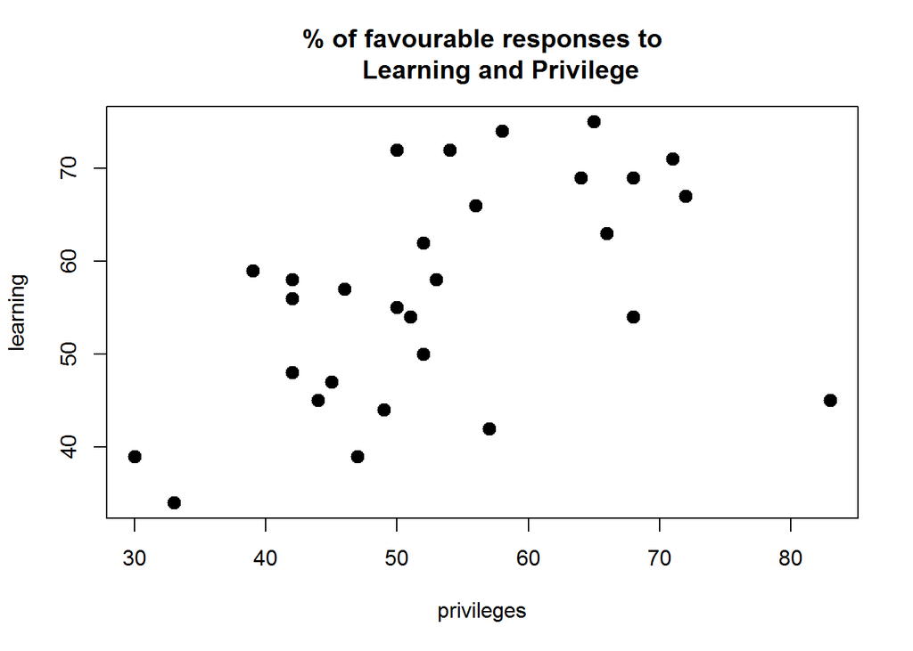

```r
# Subset the attitude data
dat = attitude[,c(3,4)]

# Plot subset data
plot(dat, main = "% of favourable responses to
     Learning and Privilege", pch =20, cex =2)
```

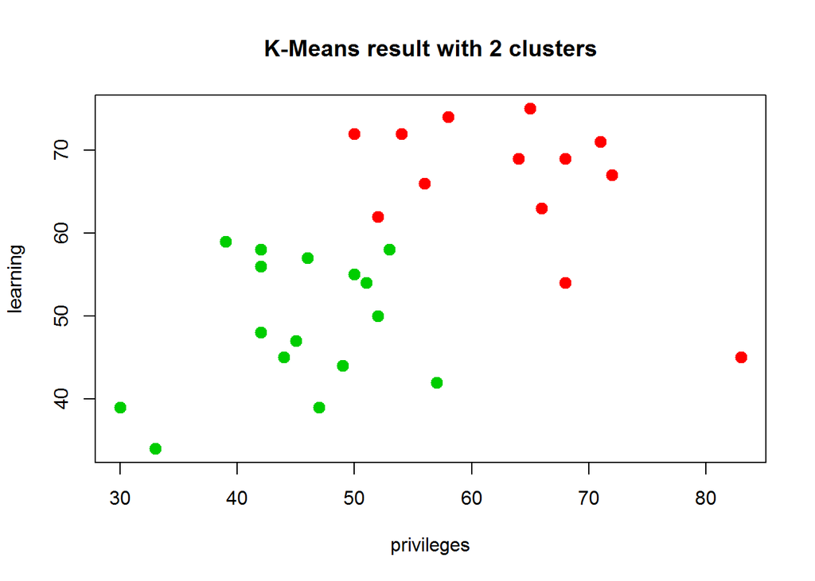

```r
# Perform K-Means with 2 clusters
set.seed(7)
km1 = kmeans(dat, 2, nstart=100)

# Plot results
plot(dat, col =(km1$cluster +1) , main="K-Means result with 2 clusters", pch=20, cex=2)
```

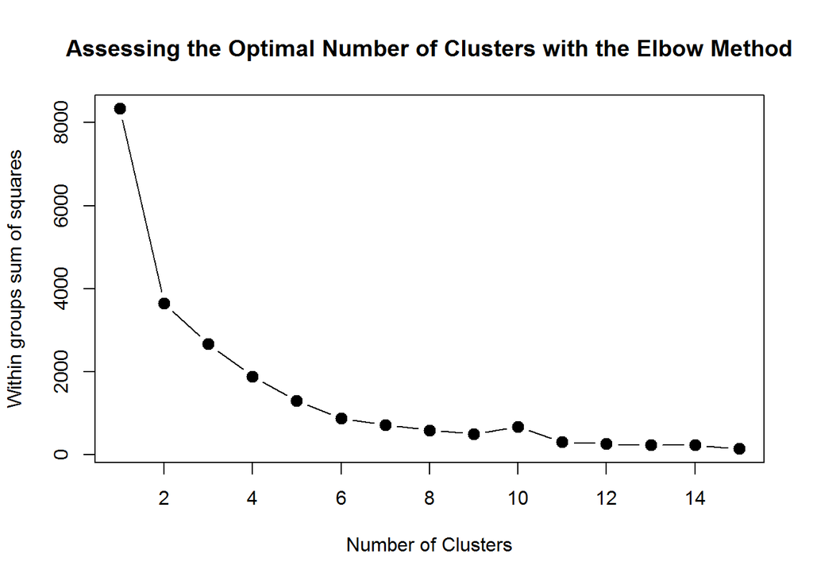

```r
# Check for the optimal number of clusters given the data
# an optimal number of clusters is identified once a “kink” in the line plot is observed
mydata <- dat
wss <- (nrow(mydata)-1)*sum(apply(mydata,2,var))
  for (i in 2:15) wss[i] <- sum(kmeans(mydata,
                                       centers=i)$withinss)
plot(1:15, wss, type="b", xlab="Number of Clusters",
     ylab="Within groups sum of squares",
     main="Assessing the Optimal Number of Clusters with the Elbow Method",
     pch=20, cex=2)
```

```r
# Perform K-Means with the optimal number of clusters identified from the Elbow method
set.seed(7)
km2 = kmeans(dat, 6, nstart=100)

# Examine the result of the clustering algorithm
km2
```

```
## K-means clustering with 6 clusters of sizes 4, 2, 8, 6, 8, 2
##
## Cluster means:
##   privileges learning
## 1   54.50000   71.000
## 2   75.50000   49.500
## 3   47.62500   45.250
## 4   67.66667   69.000
## 5   46.87500   57.375
## 6   31.50000   36.500
##
## Clustering vector:
##  [1] 6 5 4 3 1 3 5 5 4 3 5 3 3 2 1 1 4 4 5 2 6 5 3 5 3 4 1 3 4 5
##
## Within cluster sum of squares by cluster:
## [1]  71.0000 153.0000 255.3750 133.3333 244.7500  17.0000
##  (between_SS / total_SS =  89.5 %)
##
## Available components:
##
## [1] "cluster"      "centers"      "totss"        "withinss"
## [5] "tot.withinss" "betweenss"    "size"         "iter"
## [9] "ifault"
```

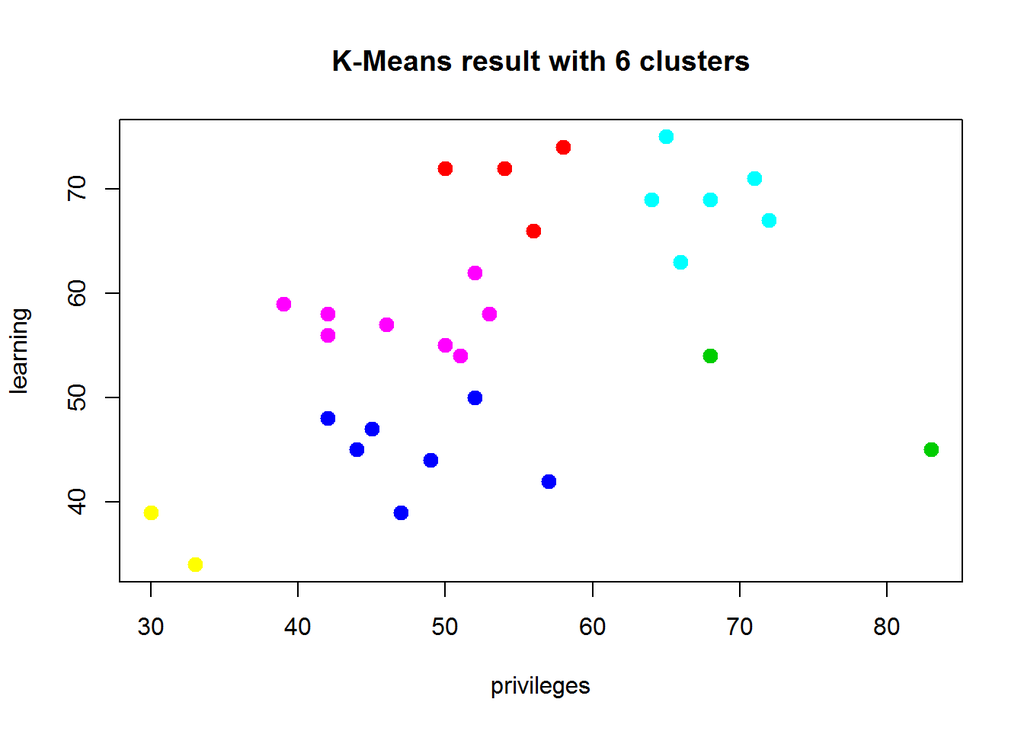

```r
# Plot results
plot(dat, col =(km2$cluster +1) , main="K-Means result with 6 clusters", pch=20, cex=2)
```